# STSCI 4630 - Lec 17

Harry Lu

March 28, 2019

**Connection between the price of a European call option and a European put option**

Binomial Tree with $T$ periods

Let $\textbf{P}$ be the price of the put, $\textbf{C}$ be the price of the call

Assume risk-free rate is $r$ per period

Claim: $\textbf{P}=\textbf{C}+(1+r)^{-T}K-S_0$, where $S_0$ is the initial price of the stock, and $K$ is the strike price of the call and put option

Consider two portfolios

1. hold the call and $(1+r)^{-T}K$ of the risk-free asset, value at expiry (i.e. in $T$ periods) is:

$$(S_T-K)_++(1+r)^T(1+r)^{-T}K=\left\{\begin{array}{l}K&,S_T\leq K\\S_T&,S_T>K\end{array}\right.$$

2. hold the put and one share of the stock, value at expiry is:

$$(K-S_T)_++S_T=\left\{\begin{array}{l}K&,S_T\leq K\\S_T&,S_T>K\end{array}\right.$$

The price of the equivalent portfolios must be the same:

$$\textbf{C}+(1+r)^{-T}K=\textbf{P}+S_0$$

Now consider a period of time of length $T$, interest rate is $r$ per unit time.

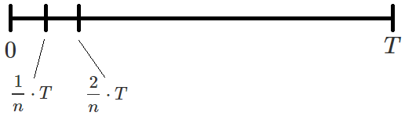

In the above graph, there are $n$ sub-intervals, and each of them has length $\frac{T}{n}$

$$\textbf{C}+\left(1+r\cdot\frac{T}{n}\right)^{-n}K-S_0=\textbf{P}$$

$$n\rightarrow\infty,\quad\textbf{C}+e^{-rT}K-S_0=\textbf{P}$$

**American v.s. European Call Option**

Early exercise of an American call option is **never** optimal. At any time before the expiration date, the price of the option is at least as great as the amount obtained by exercising the option. So American calls have the same price as European calls having the same strike price and expiration date.

But **NOT** for puts!

**Example: 2-period Binomial Tree Model**

Stock costs $\$200$, at each step the price increases or decreases by $10\%$, risk-free rate is $5\%$, put options with strike price $\$205$.

Stock:

$$200\rightarrow\left\{\begin{array}{l}220\rightarrow\left\{\begin{array}{l}242\\198\end{array}\right.\\180\rightarrow\left\{\begin{array}{l}198\\162\end{array}\right.\end{array}\right.$$

European Put Option, $K=205$

$$f_{(1)}\rightarrow\left\{\begin{array}{l}f_{(3)}\rightarrow\left\{\begin{array}{l}0\\7\end{array}\right.\\f_{(2)}\rightarrow\left\{\begin{array}{l}7\\43\end{array}\right.\end{array}\right.$$

Risk-neutral probability $q$ will be the same at all nodes:

$$q=\frac{(1.05)(200)-180}{220-180}=0.75$$

$$\begin{align}
f_{(3)}&=\frac{1}{1.05}(0\times0.75+7\times0.25)=\frac{1.75}{1.05}\\
f_{(2)}&=\frac{1}{1.05}(7\times0.75+43\times0.25)=\frac{16}{1.05}\\
f_{(1)}&=\frac{1}{1.05}\left(\frac{1.75}{1.05}\times0.75+\frac{16}{1.05}\times0.25\right)=\frac{5.3125}{1.05^2}\approx4.82
\end{align}$$

American Put Option, $K=205$

$$f_{(1)}\rightarrow\left\{\begin{array}{l}f_{(3)}\rightarrow\left\{\begin{array}{l}0\\7\end{array}\right.\\25\end{array}\right.$$

$$\begin{align}
f_{(3)}&=\frac{1}{1.05}(0\times0.75+7\times0.25)=\frac{1.75}{1.05}\\
f_{(1)}&=\frac{1}{1.05}\left(\frac{1.75}{1.05}\times0.75+25\times0.25\right)=\frac{7.875}{1.05^2}\approx7.14
\end{align}$$

**Black-Scholes Formula (1973)**

Take an interval of time $[0,1]$, $n$ sub-intervals, each of length $\frac{1}{n}$. Use continuous compounding at rate $r$ per unit time.

$$s_j\rightarrow\left\{\begin{array}{l}s_{2j+1}=s_j\cdot e^{\frac{\mu}{n}+\frac{\sigma}{\sqrt{n}}}\\s_{2j}=s_j\cdot e^{\frac{\mu}{n}-\frac{\sigma}{\sqrt{n}}}\end{array}\right.$$

$$\begin{align}
q
&=\frac{s_j\cdot e^{\frac{r}{n}}-s_j\cdot e^{\frac{\mu}{n}-\frac{\sigma}{\sqrt{n}}}}{s_j\cdot e^{\frac{\mu}{n}+\frac{\sigma}{\sqrt{n}}}-s_j\cdot e^{\frac{\mu}{n}-\frac{\sigma}{\sqrt{n}}}}\quad\text{where }e^{\frac{r}{n}}\approx1+\frac{r}{n}\\
&\approx\frac{\left(1+\frac{r}{n}\right)-\left(1+\frac{\mu}{n}-\frac{\sigma}{\sqrt{n}}+\frac{1}{2}\cdot\frac{\sigma^2}{n}\right)}{\left(1+\frac{\mu}{n}+\frac{\sigma}{\sqrt{n}}+\frac{1}{2}\cdot\frac{\sigma^2}{n}\right)-\left(1+\frac{\mu}{n}-\frac{\sigma}{\sqrt{n}}+\frac{1}{2}\cdot\frac{\sigma^2}{n}\right)}\\
&=\frac{\frac{r-\mu}{n}+\frac{\sigma}{\sqrt{n}}-\frac{1}{2}\cdot\frac{\sigma^2}{n}}{2\cdot\frac{\sigma}{\sqrt{n}}}\\
&=\frac{1}{2}\left(1-\frac{\mu-r+\frac{\sigma^2}{2}}{\sigma\sqrt{n}}\right)
\end{align}$$

Thanks to *Zhenjie Shen* for help with the notes.